# Coursera - Reproducible Research - Plotting practice

Jean-Luc BELLIER

23 juillet 2016

## Instructions

The goal of this project is to practice the plotting methods and relationships between variables of datasets.

## Question 1

Make a plot that answers the question : *what is the relationship between mean covered charges (Average.Covered.Charges) and mean total payments (Average.Total.Payments) in New-York ?

```r
paymentsDF <-  read.csv(file="payments.csv",header=TRUE, sep=",")
```

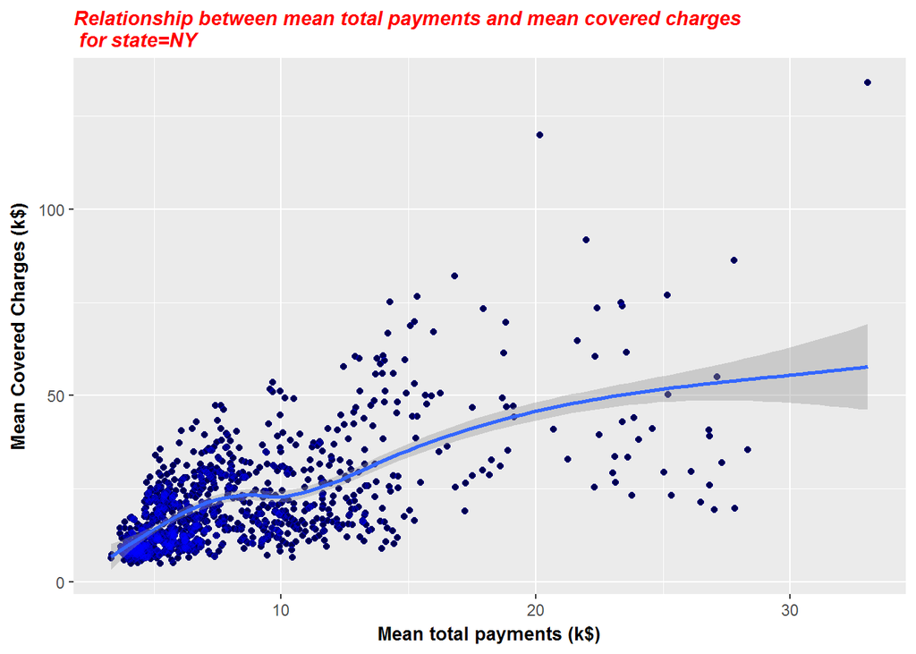

```r
library(ggplot2)
paymentsDF_NY <- subset(paymentsDF,Provider.State == "NY")
g <- qplot(Average.Total.Payments/1000, Average.Covered.Charges/1000, data=paymentsDF_NY)
mygraph <- g + geom_point(alpha=0.3, color="blue") + geom_smooth()  + labs(x="Mean total payments (k$)",y="Mean Covered Charges (k$)") + ggtitle("Relationship between mean total payments and mean covered charges\n for state=NY")
mygraph <- mygraph + theme(plot.title = element_text(color="red", size=11, face="bold.italic"), axis.title.x = element_text(size=10, face="bold"),
            axis.title.y = element_text(size=10, face="bold"))
print(mygraph)
```

```r
ggsave("plot1.pdf")
```

## Question 2

Make a plot (possibly multi-panel) that answers the question : how does the relationship between mean covered charges (Average.Covered.Charges) and mean total payments (Average.Total.Payments) vary by medical condition (DRG.Definition) and the state in which care was received (Provider.State) ?

```r
# Creation of a new device with specific size
dev2 = dev.new(width=15, height=8)
# Representation of the variations by DRG Definition. Then I drew one panel by provider state code.
# I preferred this to representing data by state code and put panels on DRG definition because I found it more clear.
#I also reduced the size of legend items and put appropriate texts on the axes and legend title.
g <- qplot(Average.Total.Payments/1000, Average.Covered.Charges/1000, data=paymentsDF,color=DRG.Definition)
mygraph <- g + geom_point(alpha=0.3, color="blue")+ facet_grid(Provider.State~.) + labs(x="Mean total payments (k$)",y="Mean Covered Charges (k$)") + ggtitle("Relationship between mean total payments and mean covered charges\n by state and medical condition")
mygraph <- mygraph + theme(plot.title = element_text(color="red", size=10, face="bold.italic"), axis.title.x = element_text(size=10, face="bold"),
            axis.title.y = element_text(size=10, face="bold"), legend.title=element_text(size=10,face="bold"), legend.text =element_text(size=7))
mygraph <- mygraph + scale_colour_discrete(name  ="Diagnosis Related Group")
dev.set(which = 2)
```

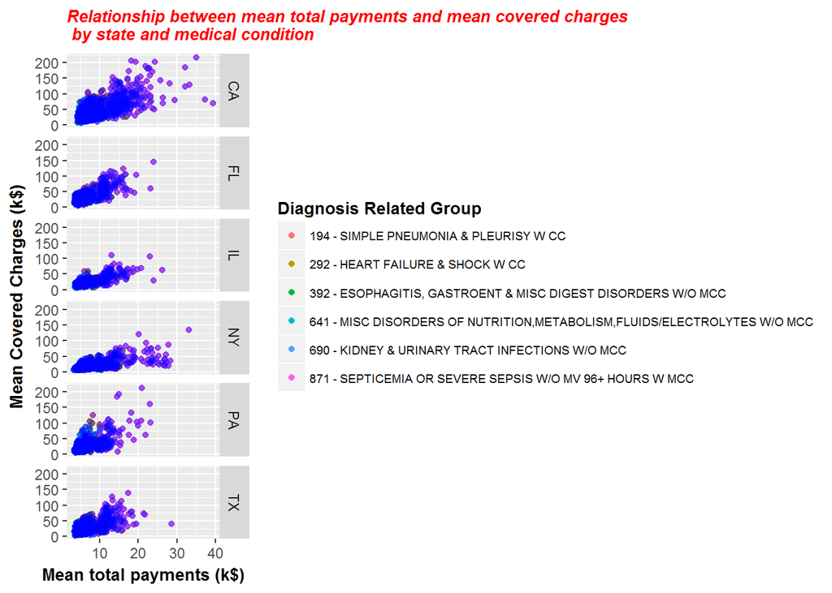

```r
print(mygraph)
```

```r
# Save the graph into PDF format
ggsave("plot2.pdf")
dev.off(which=2)
```

*Answer :* *We can notice that the highest values for mean covered charges and mean total payments can be observed for State=CA California). This is quite obvious because of the density of population in this state. Other states (like New-York) have high total payments, but quite moderate covered charges. This can illustrate the difference in different states in term of medical politics. At last, there are some ouliers with high mean total payments for each state; this can illustrate some diseases that are expensive, and not necessary taken in charge completely by the states.*.